# Projekt

2025-01-31

# Wstęp

## Opis problemu

Problemem, który analizujemy w niniejszym projekcie jest wpływ poszczególnych czynników na wynik końcowy ucznia (?)

## Baza danych

Baza danych którą analizujemy nazywa się „Wyniki uczniów”. Znajduje się w niej 20 kolumn z danymi oraz 6.608 wierszy danych. W bazie danych znajdują się zarówno zmienne liczbowe jak i jakościowe.

# Czyszczenie danych

W niniejszym rozdziale sprawdzimy jakość danych, zbadamy występowanie braków danych oraz dobierzemy odpowiednią metodę imputacji brakujących danych (jeżeli zajdzie taka potrzeba).

## Walidacja danych

- Sleep Hours - 5,22%
- Exam Score - 4,37%
- Distance from Home - 1,01%

- Family income – 309
- Sleep Hours – 300

Z uwagi na stosunkowo wysoką ilość braków dokonamy imputacji danych.

## Imputacja danych

Dokonujemy imputacji danych dla zmiennych *Exam_score* oraz *Sleep_hours* za pomocą komendy *hotdeck*. Następnie za pomocą komendy *miss_var_summary* sprawdzamy, czy imputacja zakończyła się powodzeniem. W naszym przypadku tak się stało, więc możemy przejśc do następnego kroku.

```
## # A tibble: 40 × 3
##    variable                   n_miss pct_miss
##    <chr>                       <int>    <num>
##  1 Hours_Studied                   0        0
##  2 Attendance                      0        0
##  3 Parental_Involvement            0        0
##  4 Access_to_Resources             0        0
##  5 Extracurricular_Activities      0        0
##  6 Sleep_Hours                     0        0
##  7 Previous_Scores                 0        0
##  8 Motivation_Level                0        0
##  9 Internet_Access                 0        0
## 10 Tutoring_Sessions               0        0
## # ℹ 30 more rows
```

## Reguły walidacyjne

W nineijszym rodziale tworzymy reguły walidacyjne, aby zapewnić poprawność i spójność danych. Stosujemy poniższe reguły:

```
##    name items passes fails nNA error warning
## 1   V01  6038   6038     0   0 FALSE   FALSE
## 2   V02  6038   6038     0   0 FALSE   FALSE
## 3   V03  6038   6038     0   0 FALSE   FALSE
## 4   V04  6038   6038     0   0 FALSE   FALSE
## 5   V05  6038   6038     0   0 FALSE   FALSE
## 6   V06  6038   6038     0   0 FALSE   FALSE
## 7   V07  6038   6038     0   0 FALSE   FALSE
## 8   V08  6038   6038     0   0 FALSE   FALSE
## 9   V09  6038   6038     0   0 FALSE   FALSE
## 10  V10  6038   6038     0   0 FALSE   FALSE
## 11  V11  6038   6038     0   0 FALSE   FALSE
## 12  V12  6038   6037     1   0 FALSE   FALSE
## 13  V13  6038   6038     0   0 FALSE   FALSE
## 14  V14  6038   6038     0   0 FALSE   FALSE
##                                                            expression
## 1                                         Hours_Studied - 0 >= -1e-08
## 2                                        Hours_Studied - 168 <= 1e-08
## 3                                            Attendance - 0 >= -1e-08
## 4                                           Attendance - 100 <= 1e-08
## 5                                           Sleep_Hours - 0 >= -1e-08
## 6                                           Sleep_Hours - 24 <= 1e-08
## 7                                       Previous_Scores - 0 >= -1e-08
## 8                                      Previous_Scores - 100 <= 1e-08
## 9                                     Physical_Activity - 0 >= -1e-08
## 10                                   Physical_Activity - 168 <= 1e-08
## 11                                           Exam_Score - 0 >= -1e-08
## 12                                          Exam_Score - 100 <= 1e-08
## 13  Sleep_Hours * 7 + Hours_Studied + Physical_Activity - 0 >= -1e-08
## 14 Sleep_Hours * 7 + Hours_Studied + Physical_Activity - 168 <= 1e-08
```

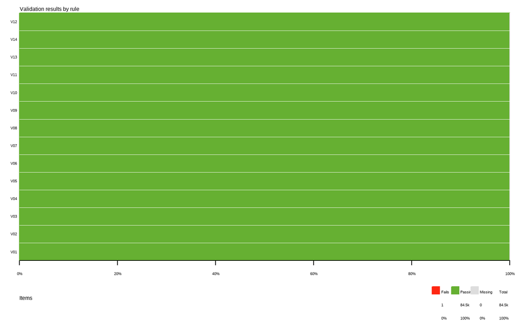

```
## call:  locate_errors(data, x, ref, ..., cl = cl, Ncpus = Ncpus)
## located  1  error(s).
## located  0  missing value(s).
## Use 'summary', 'values', '$errors' or '$weight', to explore and retrieve the errors.
```

## Wartości odstające

W tym rodziale za pomocą wykresów pudełkowych przestawiliśmy wartości odstające. Jak widać na poniższych wykresach zdarzają się wartości odstające. Szczeglnie w zmiennych *Exam_Score* oraz *Tutoring_Sessions*.

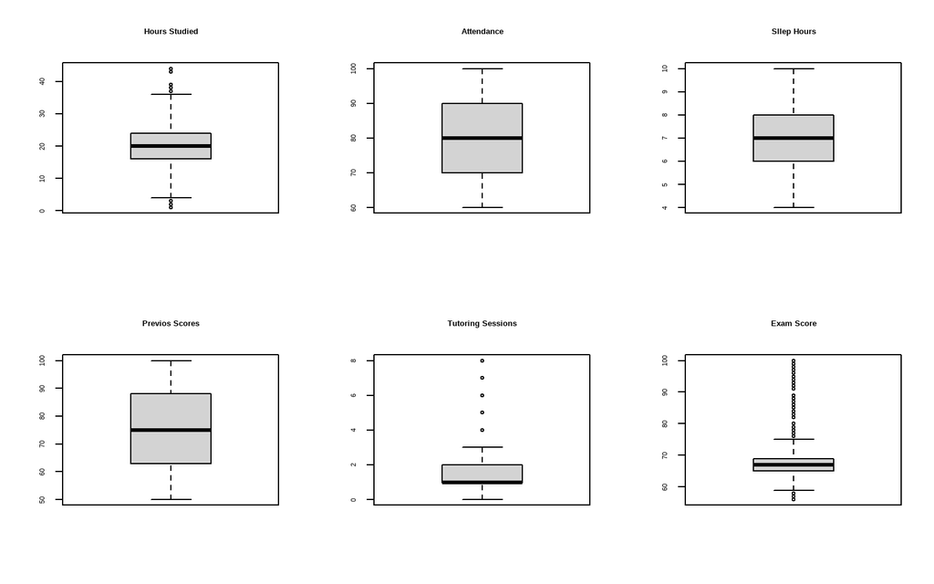

Za pomocą komendy *grubbs.test* przeprowadziliśmy test Grubbsa, który służy do wykrywania pojedyńczych wartości odstających w zbiorze danych.

Interpretacja:

- dla zmiennej *Hours_Studied* - brak odstających wartości
- dla zmiennej *Attendance* - brak odstających wartości
- dla zmiennej *Sleep_Hours* - brak odstających wartości
- dla zmiennej *Previous_Scores* - brak odstających wartości
- dla zmiennej *Tutoring_Sessions* - wartość 8 jest istotnie odstająca, lecz realna, więc nie zostanie usunięta ze zbioru danych
- dla zmiennej *Exam_Score* - wartość 100 jest istotnie odstającac, lecz realna, więc nie zostanie usunięta ze zbioru danych

```
##
##  Grubbs test for one outlier
##
## data:  dane_zwalidowane$Hours_Studied
## G = 4.01539, U = 0.99733, p-value = 0.1773
## alternative hypothesis: highest value 44 is an outlier
```

```
##
##  Grubbs test for one outlier
##
## data:  dane_zwalidowane$Attendance
## G = 1.72722, U = 0.99951, p-value = 1
## alternative hypothesis: lowest value 60 is an outlier
```

```
##
##  Grubbs test for one outlier
##
## data:  dane_zwalidowane$Sleep_Hours
## G = 2.0589, U = 0.9993, p-value = 1
## alternative hypothesis: lowest value 4 is an outlier
```

```
##
##  Grubbs test for one outlier
##
## data:  dane_zwalidowane$Previous_Scores
## G = 1.7435, U = 0.9995, p-value = 1
## alternative hypothesis: lowest value 50 is an outlier
```

```
##
##  Grubbs test for one outlier
##
## data:  dane_zwalidowane$Tutoring_Sessions
## G = 5.25143, U = 0.99543, p-value = 0.0004415
## alternative hypothesis: highest value 8 is an outlier
```

```
##
##  Grubbs test for one outlier
##
## data:  dane_zwalidowane$Exam_Score
## G = 8.42510, U = 0.98824, p-value < 2.2e-16
## alternative hypothesis: highest value 100 is an outlier
```

# Analiza i wizualizacja danych

Jak widać na wykresie poniżej, w próbce dominują mężczyźni. W zbiorze znajduje się 42 % kobiet oraz 58 % mężczyzn.

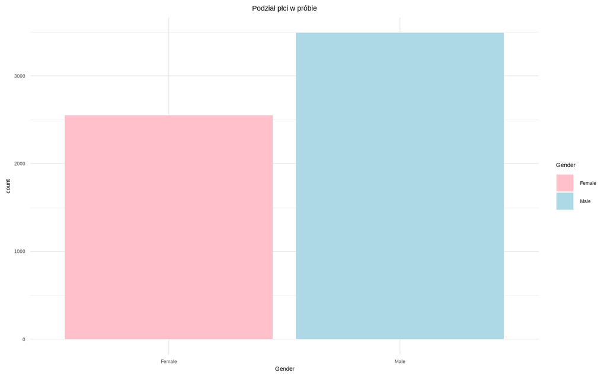

Jak widać na załączonym histogramie rozkładu zmiennej *Exam_Score* większość wyników egzaminów mieści się w zakresie 60-75 punktów. Najwięcej studentów uzyskało wynik 65-70 punktów. Wyniki powyżej 80 punktów są rzadkością.

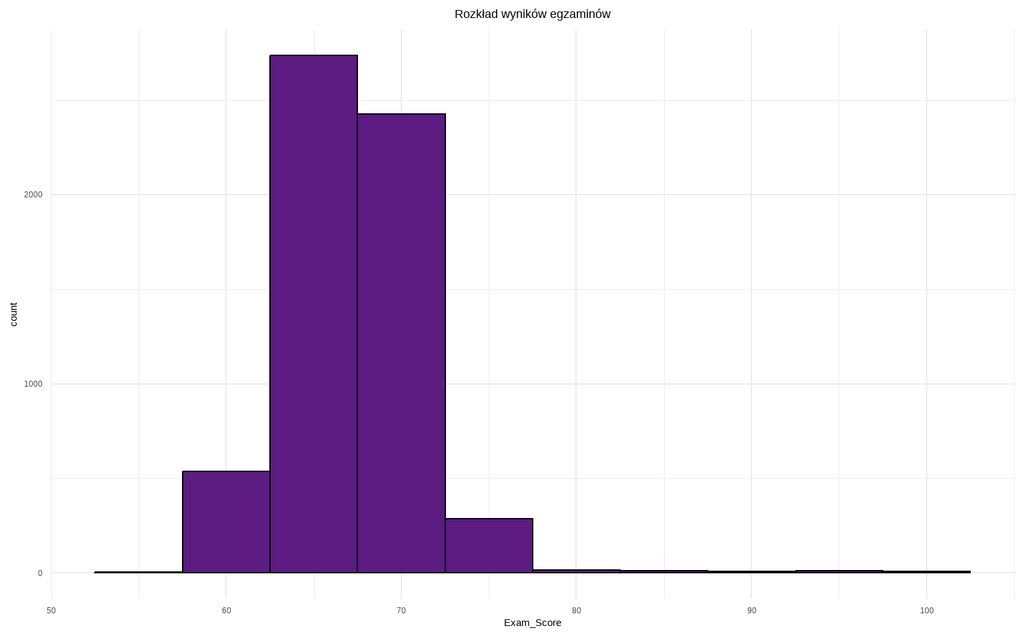

Na wykresie po lewej (kolor niebiski) przedawiono wyniki egzaminów z podziałem na płcie. Zarowno kobiety, jak i mężczyni w większości uzyskiwali wyniki w zakresie 60-75 punktów. W przypadku mężczyzn widać więcej wyników w górnej części skali (powyżej 75), lecz nie są to duże różnice. Wyniki powyżej 80 punktów są rzzadkością w obu grupach.

Wykres po prawej (kolor zielony) pokazuje ilość godzin poświęconych na naukę tygodniowo w podziale na płcie. W obu grupach większość uczy się 15-25 godzin tygodniowo. Nauka powyżej 40 godzin tygodiowo jest żadkością w obu grupach.

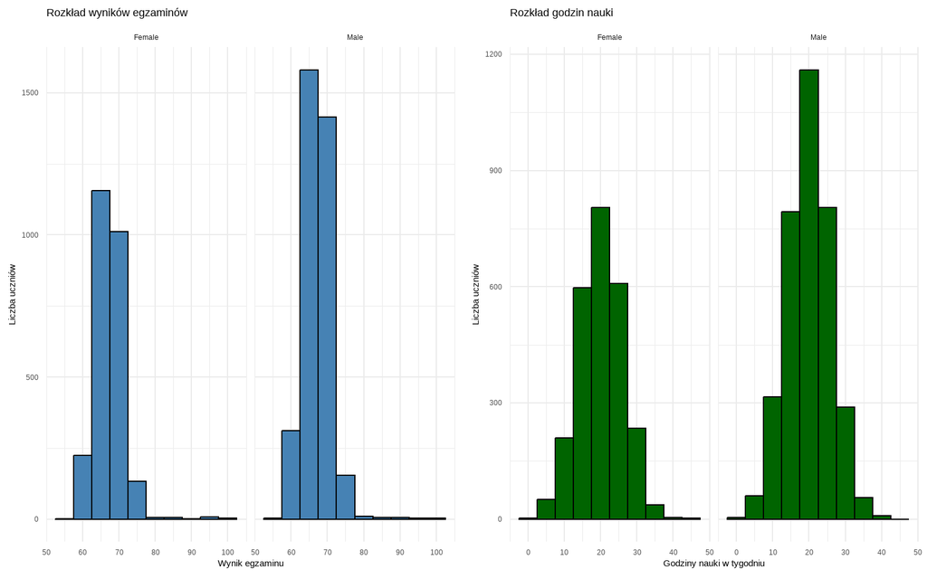

Poniższy wykres rozrzutu przestawia relację między zmienną *Hours_Studied* a *Exam_Score*. Czerowna linia regresji sugeruje lekkko poytywną korelację - więcej godzin nauki często wiąże się z lepszym wynikiem. Widzimy, że większość studentów uczy się od 5 do 30 godzin tygodniowo i osiąga wyniki z przedziału 60-80.

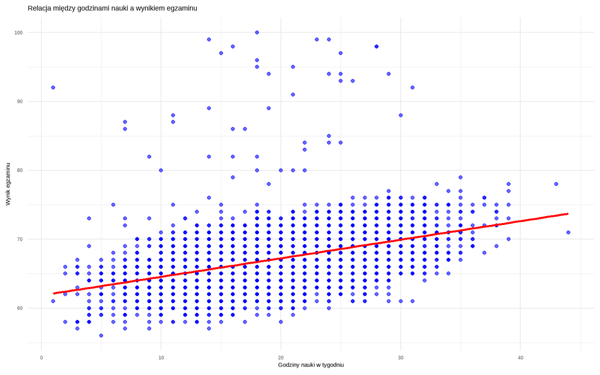

Prezentowany poniżej wykres wiolinowy pokazuje zależność pomiędzy zmienną *Parental_Involvment* a *Exam_Score*. W zbiorze zaanagażowanie rodziców określone jest w 3 stopniach - *Low*, *Medium* oraz *High*.

- wysokie zaangażowanie rodziców - wyniki są z reguły wyższe niż w innych grupach, najczęściej występują wartości z przedziału 65-70
- średnie zaangażowanie rodziców - wyniki skupiają się w przedziale 65-70, lecz na wysokości 70 wykres jest węższy niż dla grupy z wysokim zaangażowaniem
- niskie zaangażowanie rodziców - wyniki skupiają się w okolicy wartości 65 i osiągają niższe wartości niż dwie pozostałe grupy

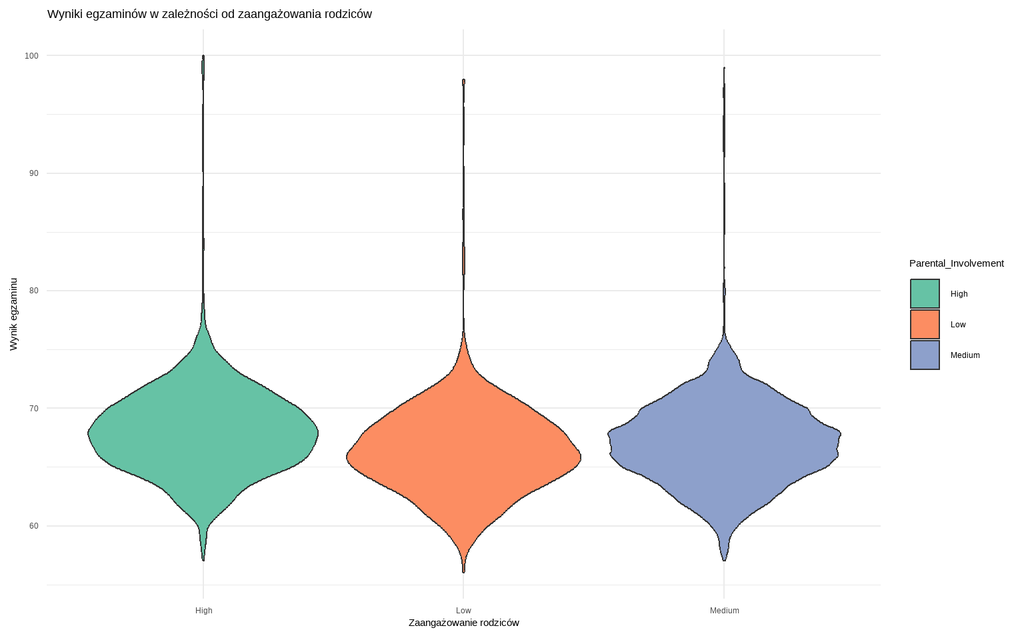

Poniższy wykres słupkowy pokazuje typ szkół do których uczęszczają badani. Zdecydowana większość próbki uczęszcza do publicznych placówek edukacyjnych.

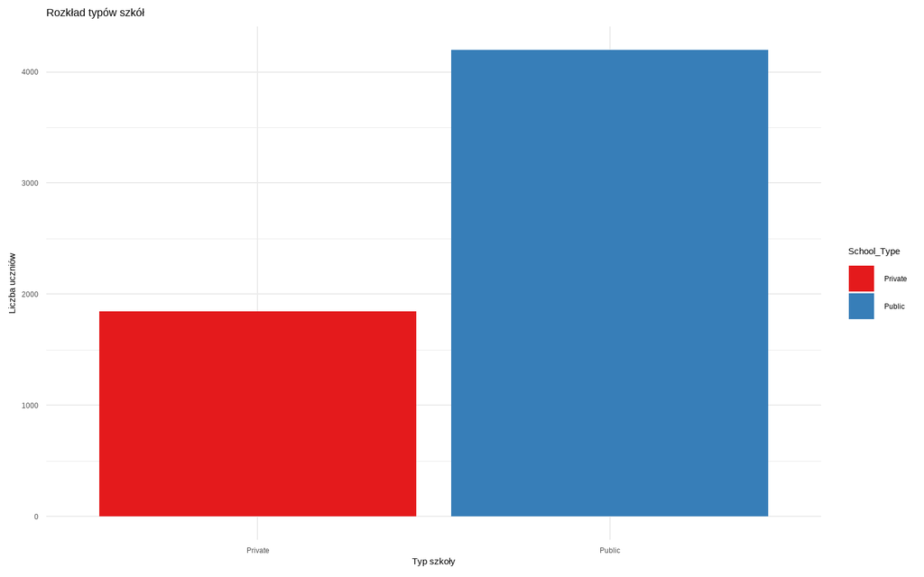

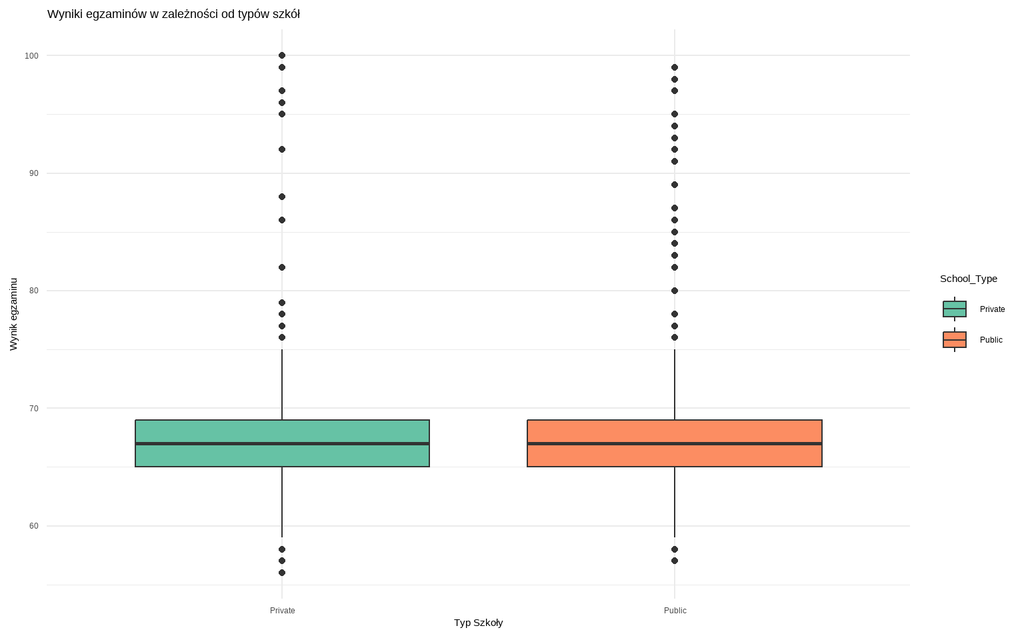

Poniższe wykresy typu Boxplot pokazują zależności pomiędzy zmiennymi *Parental_Involvement*, *Motivation_Level* a *Exam_Scores*.

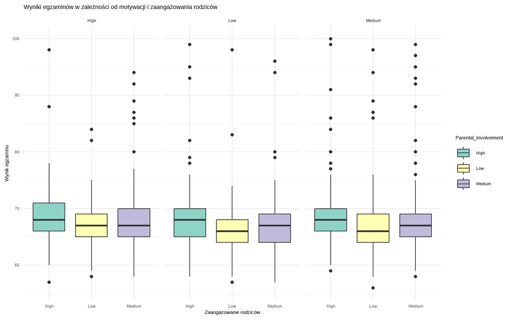

Poniższy wykres przedstawia zależność pomiędzy zmiennymi *Acces_to_Resources* (określone w wartościach *High*, *Medium* oraz *Low*), *Internet_Access* (*Yes* lub *No*) a zmienną *Exam_Score*. Na wykresie widzimy, że osoby posiadające wysoki dostęp do źródeł osiągają wyższe wyniki, niż osoby o średnim i niskim dostępie. Widzimy rownież, że osoby posiadające dostęp do internetu osiągają wyższe niż osoby o tym samym poziomie dostępu do źródeł, a braku dostępu do internetu. Możemy z tego wywnioskować, że brak dostępu do zasobów edukacyjnych i internetu negatywnie wpływa na wyniki egzaminów.

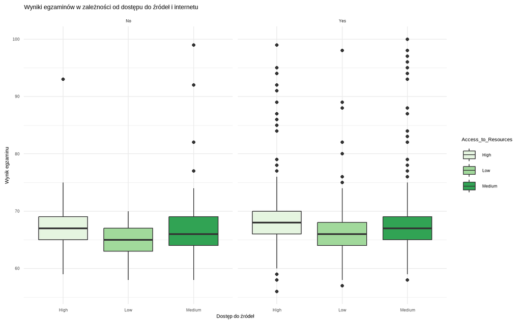

Poniższy wykres rozrzutu przestawia relację między zmienną *Previous_Score* a *Exam_Score*. Różowa linia regresji sugeruje lekkko poytywną korelację - wyższy wynik z wcześniejszych egzaminów może delikatnie pozytywnie wpływać na lepszy wynik egzaminu końcowego. Rozkład jest równomierny, większość obserwacji jest zbliżona do osi.

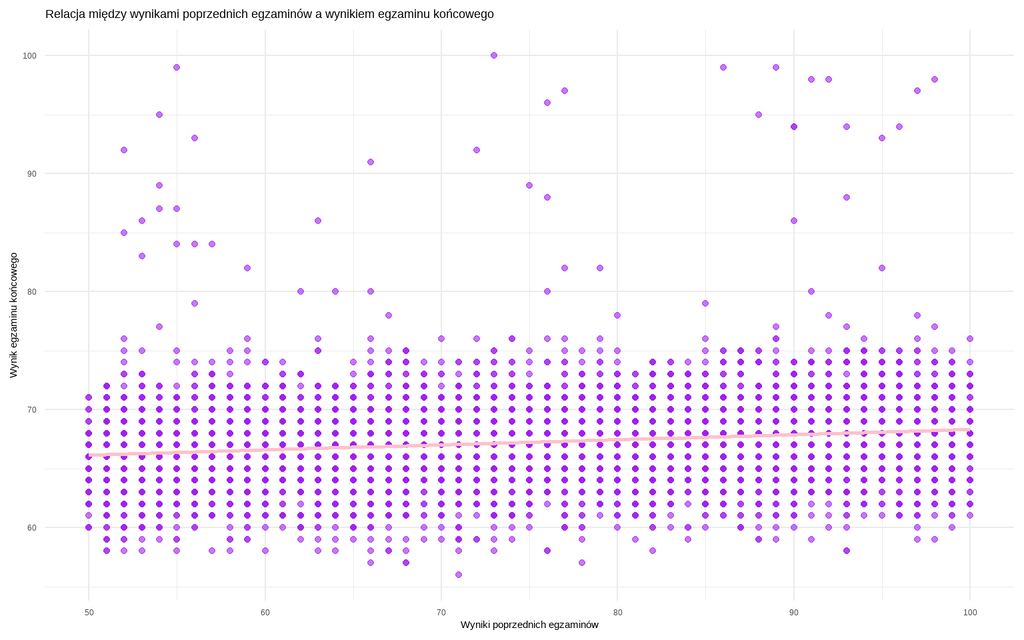

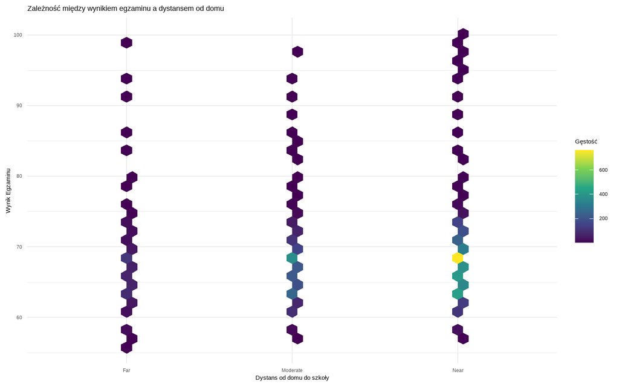

Poniższy diagram kołowy prezentuje rozkład zmiennej *Learning_Disabilities* * 10,5 % badanej próbki posiada trudności w uczeniu się * 89,5 % badanej próbki nie posiada trudności w nauce

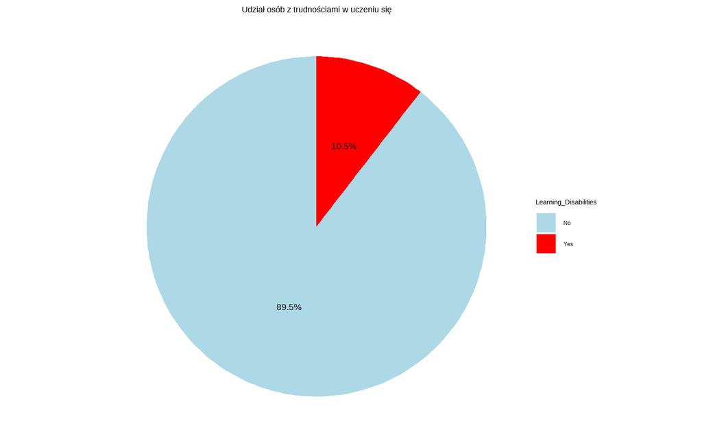

```r
ld_counts <- dane_zwalidowane %>%
  count(Learning_Disabilities)%>%
  mutate(Percentage =round(n /sum(n)*100,1))# Zaokrąglamy do 1 miejsca po przecinku# Tworzenie wykresu kołowego
ggplot(ld_counts, aes(x ="", y = n, fill = Learning_Disabilities))+
  geom_bar(stat ="identity", width =1)+
  coord_polar("y", start =0)+
  scale_fill_manual(values =c("Yes"="red","No"="lightblue"))+
  theme_void()+
  ggtitle("Udział osób z trudnościami w uczeniu się")+
  theme(plot.title = element_text(hjust =0.5))+
  geom_text(aes(label = paste0(Percentage,"%")),
            position = position_stack(vjust =0.5),
            color ="black", size =5)
```

Poniższy wykres słupkowy przedstawia zależność między zmienną *Parental_Education_Level* a *Exam_Score*. Wnioski: * Największa liczba uczniów pochodzi z rodzin, w których rodzice mają wykształcenie średnie (High School) – w tej grupie słupki są najwyższe. * Rozkład wyników jest podobny dla każdej grupy – wyniki oscylują głównie w przedziale 60-75 punktów. * Rodzice z wyższym wykształceniem (Postgraduate, College) – ich dzieci osiągają nieco wyższe wyniki w porównaniu do grupy “High School”. * Wysokie wyniki (90-100 punktów) są rzadkie – niezależnie od poziomu wykształcenia rodziców, liczba uczniów z bardzo wysokimi wynikami jest niewielka.

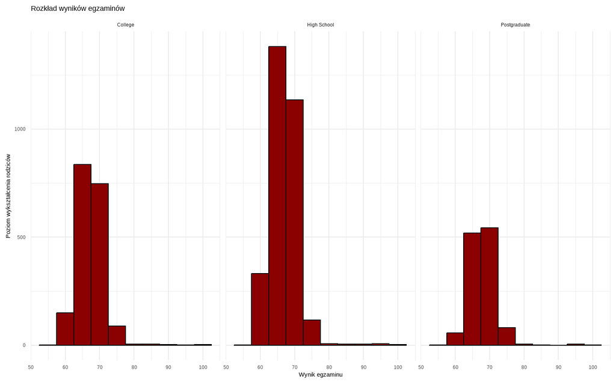

```r
ggplot(dane_zwalidowane, aes(x = Exam_Score))+
  geom_histogram(binwidth =5, fill ="darkred", color ="black")+
  theme_minimal()+
  labs(title ="Rozkład wyników egzaminów", x ="Wynik egzaminu", y ="Poziom wykształcenia rodziców")+
  facet_grid(~Parental_Education_Level)
```

Wykres poniżej przedstawia wpływ zmiennej *Teacher_Quality* (wyrażonej w wartościach *Low*, *Medium* lub *High*) na *Exam_Results*. W przypadku niskiej i średniej jakości nauczycieli mediana wyników z egzaminów wynosi 67. Uczniowie wysokiej jakości nauczycieli osiągają wyniki z medianą na poziomie 68. Wynika z tego, że jakość nauczyciela ma niewielki pozytywny wpływ na medianę wyników uczniów.

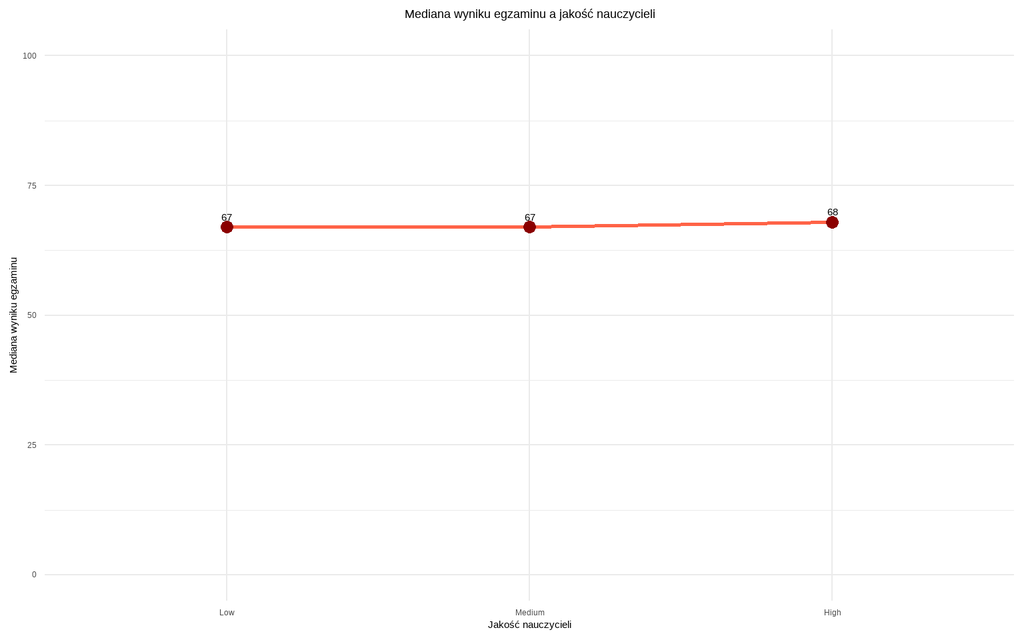

Wykres poniżej ukazuje relacje między zmienną *Family_Income* (wyrażony w wartościach *Low*, *Medium* oraz *High*) a *Tuttoring_Sessions* (wartości z zakresu 0-8). Jak widać na wykresie nie ma wyraźnych zależności pomiędzy dochodem rodziny, a ilością korepetycji.

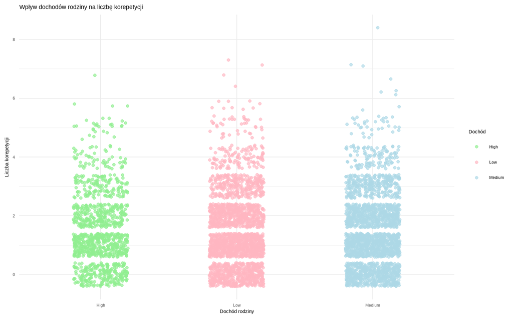

```r
ggplot(dane_zwalidowane, aes(x = Family_Income, y = Tutoring_Sessions, color = Family_Income)) +
  geom_jitter(width = 0.2, alpha = 0.7) + # Dodanie punktów z małym zakłóceniem na osi X (w celu uniknięcia nakładania punktów)
  geom_smooth(method = "lm", se = FALSE, color = "black") + # Linia trendu (regresji liniowej)
  scale_color_manual(values = c("High" = "lightgreen", "Medium" = "lightblue", "Low" = "lightpink")) +
  theme_minimal() +
  labs(
    title = "Wpływ dochodów rodziny na liczbę korepetycji",
    x = "Dochód rodziny",
    y = "Liczba korepetycji",
    color = "Dochód"
  )
```

Poniższy wykres kołowy pokazuje procentowy podział zmiennej *Family_Income*.

- 19,2% należy do kategorii *High*, czyli wysokie dochody rodziny
- 40,3% należy do kategorii *Medium*, czyli średnie dochody rodziny
- 40,5% należy do kategorii *Low*, czyli niskie dochody rodziny

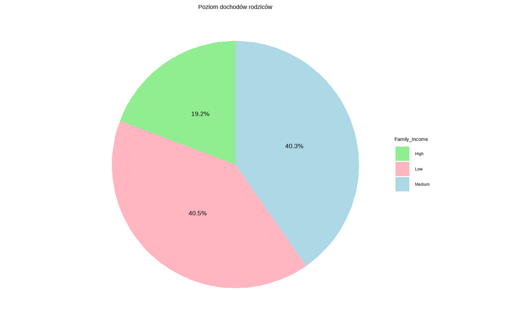

Poniższy wykres pokazuje zależność między zmienną *Sllep_Hours* a *Exam_Score*. Widziamy na nim, że bez względu na ilość snu zdecydowana większośc wyników znajduje się w przedziale 60-75. Pomarańczowa linia reprezentująca korelacje pokazuje jest pozioma, co pokazuje brak korelacji pomiędzy ilością snu a wynikiem z egzaminu. Na podstawie gęstości umieszczenia kropek na wykresie możemy zauważyć, że najwięcej osób śpi między 6 a 8 godzin dziennie.

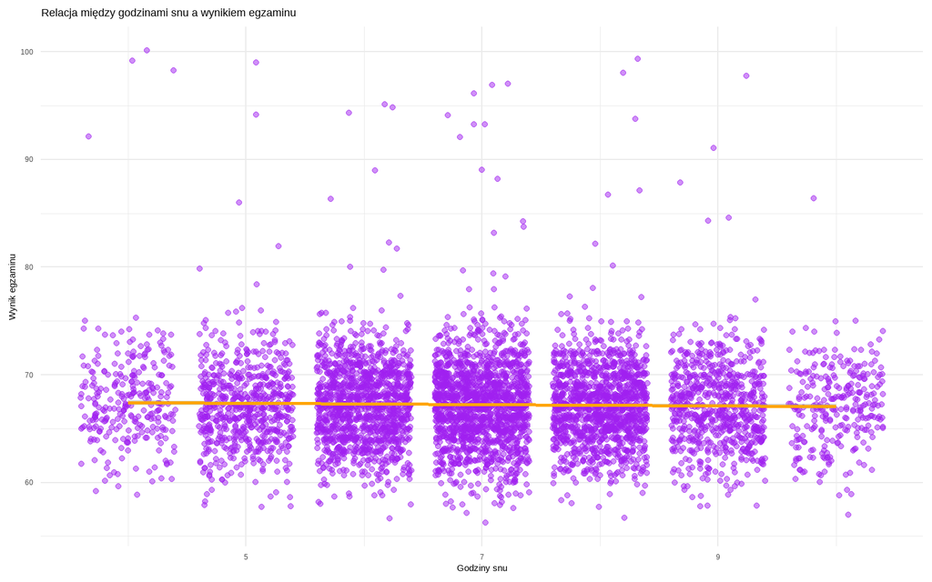

# Statystki Opisowe

## Statystyki opisowe dla zmiennych ilościowych

Z tabeli poniżej możemy odczytać statystyki opisowe dla zmiennej *Hours_Studied* Widzimy, że wartości średniej i mediany są do siebie zbliżone i wynoszą odpowiednio 19,99 oraz 20. Odchylenie standardowe można uznać za umiarkowane. Wartości tej zmiennej mieszczą się z zakresie od 1 do 44.

Statystyki Opisowe:

Hours_Studied

| Rodzaj statystyki | Wartość |
| --- | --- |
| średnia | 19.99 |
| mediana | 20.00 |
| odchylenie_standardowe | 5.98 |
| minimum | 1.00 |
| maksimum | 44.00 |

Z tabeli poniżej możemy odczytać statystyki opisowe dla zmiennej *Attendance* Widzimy, że wartości średniej i mediany są do siebie zbliżone i wynoszą odpowiednio 80,02 oraz 80. Odchylenie standardowe można uznać za umiarkowane. Wartości tej zmiennej mieszczą się z zakresie od 60 do 100.

Statystyki Opisowe:

Attendance

| Rodzaj statystyki | Wartość |
| --- | --- |
| średnia | 80.02 |
| mediana | 80.00 |
| odchylenie_standardowe | 11.59 |
| minimum | 60.00 |
| maksimum | 100.00 |

Statystyki Opisowe:

Sleep_Hours

| Rodzaj statystyki | Wartość |
| --- | --- |
| średnia | 7.03 |
| mediana | 7.00 |
| odchylenie_standardowe | 1.47 |
| minimum | 4.00 |
| maksimum | 10.00 |

Z tabeli poniżej możemy odczytać statystyki opisowe dla zmiennej *Tuttoring_Sessions* Widzimy, że wartości średniej i mediany wynoszą odpowiednio 1,5 oraz 1,00. Odchylenie standardowe jest duże. W praktyce oznacza to, że ilość godzin korepetycji jest zróźnicowana wśród uczniów Wartości tej zmiennej mieszczą się z zakresie od 0 do 8.

Statystyki Opisowe:

Tutoring_Sessions

| Rodzaj statystyki | Wartość |
| --- | --- |
| średnia | 1.50 |
| mediana | 1.00 |
| odchylenie_standardowe | 1.24 |
| minimum | 0.00 |
| maksimum | 8.00 |

Z tabeli poniżej możemy odczytać statystyki opisowe dla zmiennej *Phisical_Activity* Widzimy, że wartości średniej i mediany są do siebie zbliżone i wynoszą odpowiednio 2,97 oraz 3. Odchylenie standardowe można uznać za umiarkowane. Wartości tej zmiennej mieszczą się z zakresie od 0 do 6.

Statystyki Opisowe:

Physical_Activity

| Rodzaj statystyki | Wartość |
| --- | --- |
| średnia | 2.97 |
| mediana | 3.00 |
| odchylenie_standardowe | 1.03 |
| minimum | 0.00 |
| maksimum | 6.00 |

Z tabeli poniżej możemy odczytać statystyki opisowe dla zmiennej *Exam_Sconre* Widzimy, że wartości średniej i mediany są do siebie zbliżone i wynoszą odpowiednio 67,24 oraz 67. Odchylenie standardowe można uznać za umiarkowane. Wartości tej zmiennej mieszczą się z zakresie od 56 do 100.

Statystyki Opisowe:

Exam_Score

| Rodzaj statystyki | Wartość |
| --- | --- |
| średnia | 67.24 |
| mediana | 67.00 |
| odchylenie_standardowe | 3.89 |
| minimum | 56.00 |
| maksimum | 100.00 |

Wykres poniżej przedstawia macierz korelacji. Uwzględnia on wpływ zmiennych *Hours_Studied*, *Attendance*, *Sleep_Hours*, *Previous_Scores*, *Tutoring_Sesions*, *Phisical_Activity* na zmienną *Exam_Score*.

- *Hours_Studied* - istnieje wyraźna dodatnia korelacja, co sugeruje, że więcej godzin nauki jest związane z wyższymi wynikami egzaminów.
- *Attendance* - istnieje wyraźna dodatnia korelacja, co sugeruje, że czym wyższa obecność na zajęciach, tym wyższe wyniki z egzaminu.
- *Sleep_Hours* - korelacja jest bardzo słaba, albo nie ma jej wcale
- *Previous_Scores* - korelacja jest dodatnia, ale słaba, więc można z tego wywynioskwać, że wyniki poprzednich egzaminów mają niewielki wpływ na obecną ocenę studenta. Wysokie wyniki w przeszłości dają niewielkie prawdpodobieństwo osiągnięcia wyższych wyników obecnie
- *Tutoring_Sesions* - korelacja jest dodatnia, ale bardzo słaba. Możemy to zinterpretować jako: Więcej sesji korepetycji może (ale nie musi) prowadzić do wyższego wyniku z egzaminu
- *Phisical_Activity* - korelacja jest bardzo słaba, albo nie ma jej wcale

```
##                   Hours_Studied   Attendance  Sleep_Hours Previous_Scores
## Hours_Studied       1.000000000 -0.001527627  0.013153477     0.017698977
## Attendance         -0.001527627  1.000000000 -0.016599381    -0.016306714
## Sleep_Hours         0.013153477 -0.016599381  1.000000000    -0.022029887
## Previous_Scores     0.017698977 -0.016306714 -0.022029887     1.000000000
## Tutoring_Sessions  -0.013941975  0.014743286 -0.009616925    -0.020365357
## Physical_Activity   0.005044221 -0.018809595 -0.002628321    -0.005460835
## Exam_Score          0.414726061  0.553460602 -0.022759225     0.159383131
##                   Tutoring_Sessions Physical_Activity  Exam_Score
## Hours_Studied          -0.013941975       0.005044221  0.41472606
## Attendance              0.014743286      -0.018809595  0.55346060
## Sleep_Hours            -0.009616925      -0.002628321 -0.02275923
## Previous_Scores        -0.020365357      -0.005460835  0.15938313
## Tutoring_Sessions       1.000000000       0.015166600  0.13825055
## Physical_Activity       0.015166600       1.000000000  0.03130742
## Exam_Score              0.138250550       0.031307422  1.00000000
```

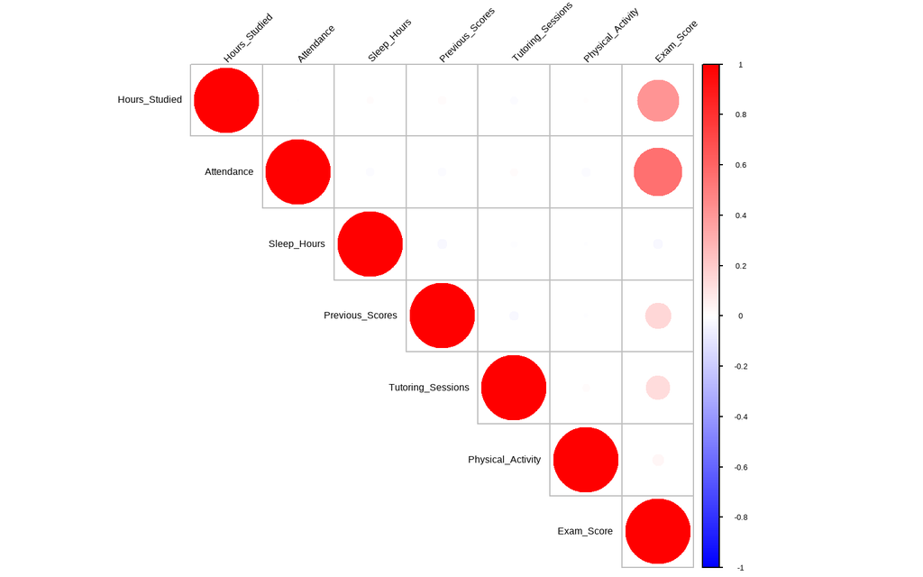

## Wnioskowanie statystyczne

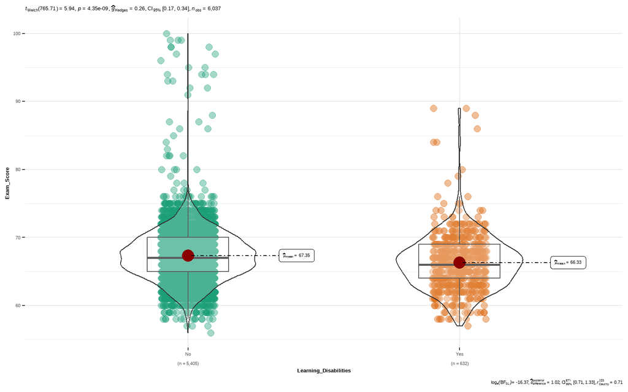

Wykres wiolinowy widoczny poniżej prezentuje zależność między zmienną *Extracurricular_Activities* a *Exam_Score*. Jak widać na wykresie, średni wynik z egzaminu dla osób korzsytających z zajęć dodatkowych wynosi 67,46, a dla osób nie korzystających z zajęć dodatkowych 66,92. Dla osób korzystających z zajęć dodatkowych widzimy więcej wyników z przedziału 95-100. Mimo że uczniowie biorący udział w zajęciach pozaszkolnych mają nieco wyższe wyniki egzaminów, różnica ta jest statystycznie istotna, ale niewielka, co wynika z wartości współczynnika Hedges’a oraz analizy Bayesowskiej.

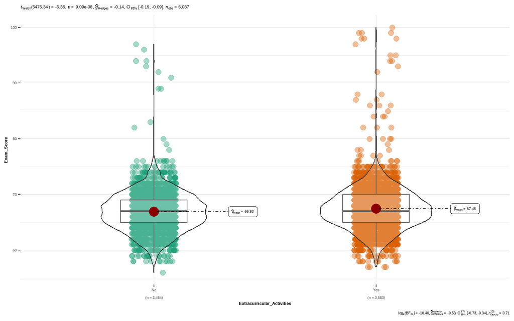

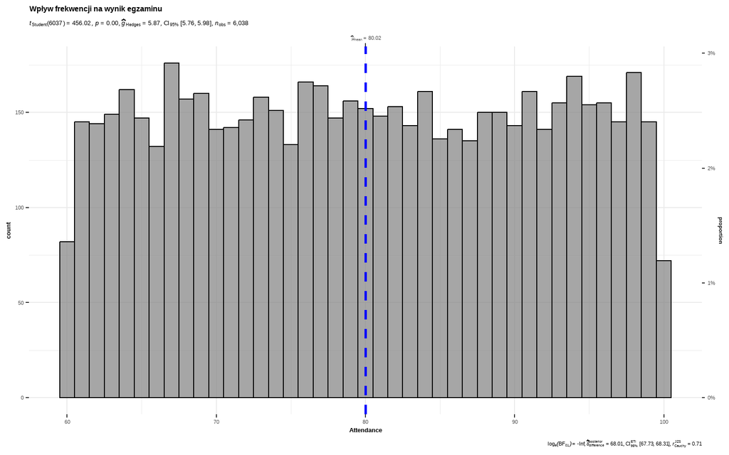

```r
set.seed(123)
  gghistostats(
  data       = dane_zwalidowane,
  x          = Attendance,
  title      = "Wpływ frekwencji na wynik egzaminu",
  test.value = 12,
  binwidth   = 1
)
```